# Análisis estadístico sobre los mejores 1200 jugadores del servidor de Norte América en el Juego Valorant y sus estadísticas

## Relacion Rango-Headshot

[figure not shown]

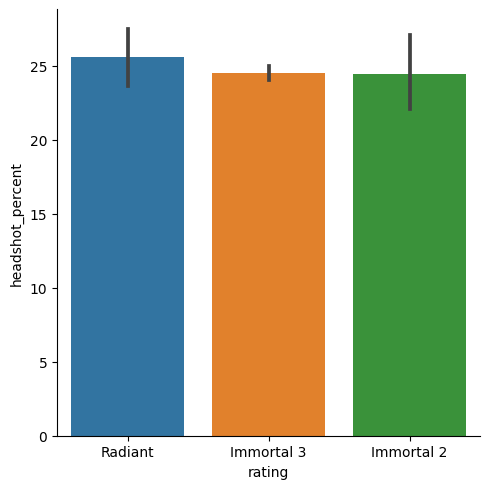

```python
sns.catplot(x="rating", y="headshot_percent", data=val,
            kind="bar")
plt.show()
```

## Relacion Agentes-Victorias

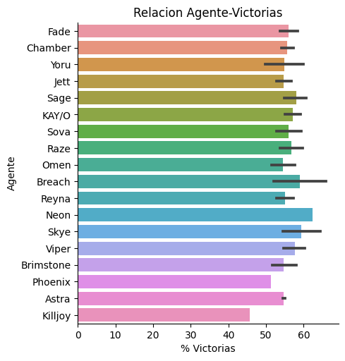

```python
sns.catplot(x="win_percent", y="agent_1", data=val,
            kind="bar")
plt.xlabel("% Victorias")
plt.ylabel("Agente")
plt.title("Relacion Agente-Victorias")
plt.show()
```

### Segun los datos, el agente que mas conviene usar para obtener la victoria seria "Neon"

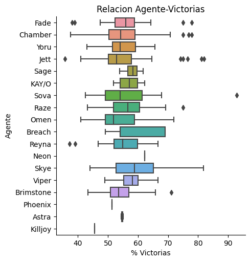

```python
sns.catplot(x="win_percent", y="agent_1", data=val,
            kind="box")
plt.xlabel("% Victorias")
plt.ylabel("Agente")
plt.title("Relacion Agente-Victorias")
plt.show()
```

## Relacion Arma-Headshot

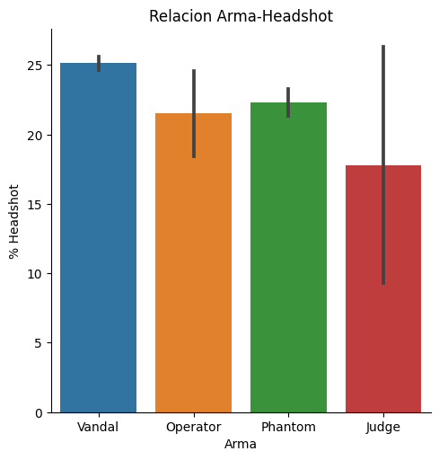

```python
sns.catplot(x="gun1_name", y="headshot_percent", data=val,
            kind="bar")

plt.xlabel("Arma")
plt.ylabel("% Headshot")
plt.title("Relacion Arma-Headshot")
plt.show()
```

### Se puede observar una clara ventaja de la Vandal en lo que a porcentaje de tiros a la cabeza respecta.

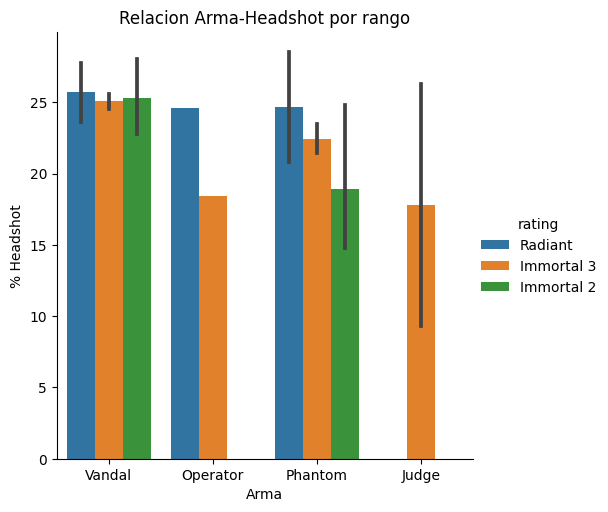

```python
sns.catplot(x="gun1_name", y="headshot_percent", data=val,
            kind="bar",hue = "rating")

plt.xlabel("Arma")
plt.ylabel("% Headshot")
plt.title("Relacion Arma-Headshot por rango")
plt.show()
```

## Relacion KDA-Agentes

### KDA es la relacion entre Kills,Death,Assists.

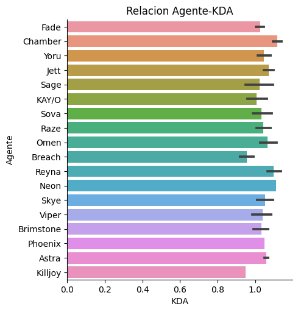

```python
sns.catplot(x="kd_ratio", y="agent_1", data=val,
            kind="bar")
plt.xlabel("KDA")
plt.ylabel("Agente")
plt.title("Relacion Agente-KDA")
plt.show()
```

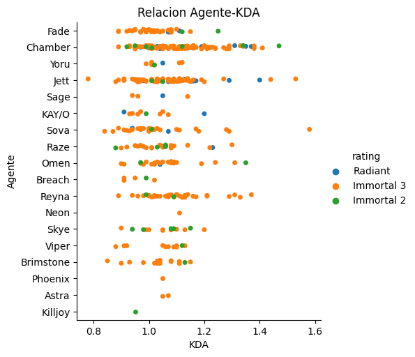

```python
sns.catplot(x="kd_ratio", y="agent_1", data=val,
           kind="strip", hue="rating")
plt.xlabel("KDA")
plt.ylabel("Agente")
plt.title("Relacion Agente-KDA")
plt.show()
```

## Relacion Rango-First Blood

### First Blood se refiere a ser el jugador que realice la primera eliminacion en la ronda

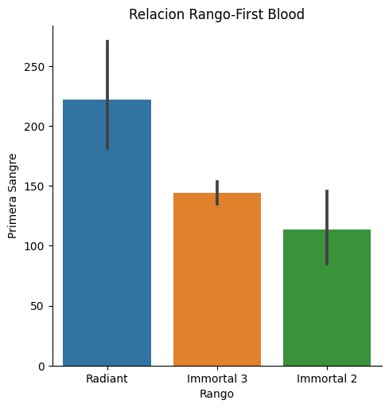

```python
sns.catplot(x="rating", y="first_bloods", data=val,
            kind="bar")

plt.xlabel("Rango")
plt.ylabel("Primera Sangre")
plt.title("Relacion Rango-First Blood")
plt.show()
```

### Se puede observar un crecimiento bastante significativo entre los diferentes rangos.

### Lo que muestra que los jugadores que alcanzan el rango "Radiante", suelen tomar el riesgo de intentar la primera sangre de cada ronda

## Relacion entre Rango-Clutches

[figure not shown]

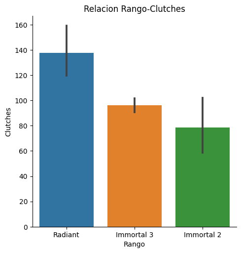

```python
sns.catplot(x="rating", y="clutches", data=val,
            kind="bar")

plt.xlabel("Rango")
plt.ylabel("Clutches")
plt.title("Relacion Rango-Clutches")
plt.show()
```